# Generate Output

## Load Packages

```r
# install.packages("fda")
# devtools::install_github("rmflight/knitrProgressBar")
library(fda)
library(knitrProgressBar)
```

## Load Functions

```r
for(file in list.files(path="src",full.names=TRUE)){
  source(file=file)
}
```

## Set Seed

```r
# consistent across all R versions
# source: Phil, kangaroo_cliff, bschneidr, luchonacho, & cdermont. (2022, October 12). Is set.seed consistent over different versions of R (and ubuntu)?. Stack Overflow. https://stackoverflow.com/questions/47199415/is-set-seed-consistent-over-different-versions-of-r-and-ubuntu
set.seed(seed=1,sample.kind="Rounding")
```

## Figure 1

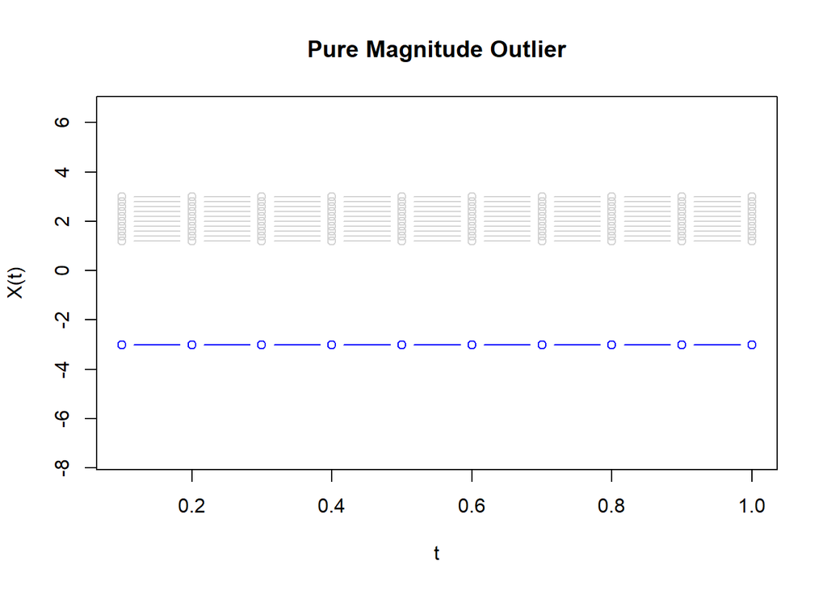

```
## $legend
## $legend[[1]]
## [1] "f=pure magnitude outlier"
##
## $legend[[2]]
## [1] "pointwiseMedian=pointwise median"
##
##
## $results
##                            [,1]  [,2]  [,3]  [,4]  [,5]  [,6]  [,7]  [,8]  [,9] [,10]
## t                         0.100 0.200 0.300 0.400 0.500 0.600 0.700 0.800 0.900 1.000
## Var(R_pointwiseMedian(t)) 0.248 0.248 0.248 0.248 0.248 0.248 0.248 0.248 0.248 0.248
## Var(R_f(t))               0.083 0.083 0.083 0.083 0.083 0.083 0.083 0.083 0.083 0.083
## Var(E(R_f(t)|R_f(t-Δ)))      NA 0.083 0.083 0.083 0.083 0.083 0.083 0.083 0.083 0.083
## E(Var(R_f(t)|R_f(t-Δ)))      NA 0.000 0.000 0.000 0.000 0.000 0.000 0.000 0.000 0.000
```

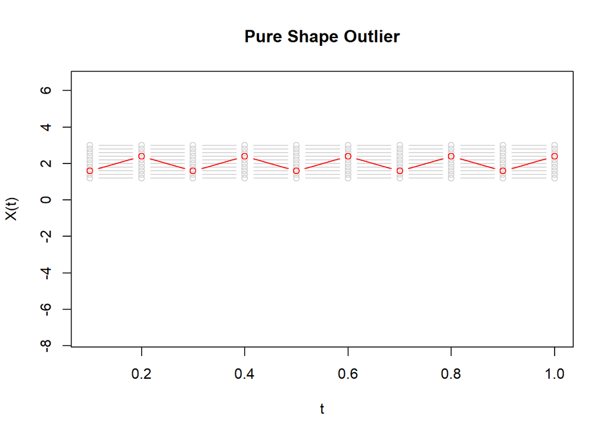

```
## $legend
## $legend[[1]]
## [1] "f=pure shape outlier"
##
## $legend[[2]]
## [1] "pointwiseMedian=pointwise median"
##
##
## $results
##                            [,1]  [,2]  [,3]  [,4]  [,5]  [,6]  [,7]  [,8]  [,9] [,10]
## t                         0.100 0.200 0.300 0.400 0.500 0.600 0.700 0.800 0.900 1.000
## Var(R_pointwiseMedian(t)) 0.248 0.248 0.248 0.248 0.248 0.248 0.248 0.248 0.248 0.248
## Var(R_f(t))               0.231 0.198 0.231 0.198 0.231 0.198 0.231 0.198 0.231 0.198
## Var(E(R_f(t)|R_f(t-Δ)))      NA 0.043 0.050 0.043 0.050 0.043 0.050 0.043 0.050 0.043
## E(Var(R_f(t)|R_f(t-Δ)))      NA 0.156 0.182 0.156 0.182 0.156 0.182 0.156 0.182 0.156
```

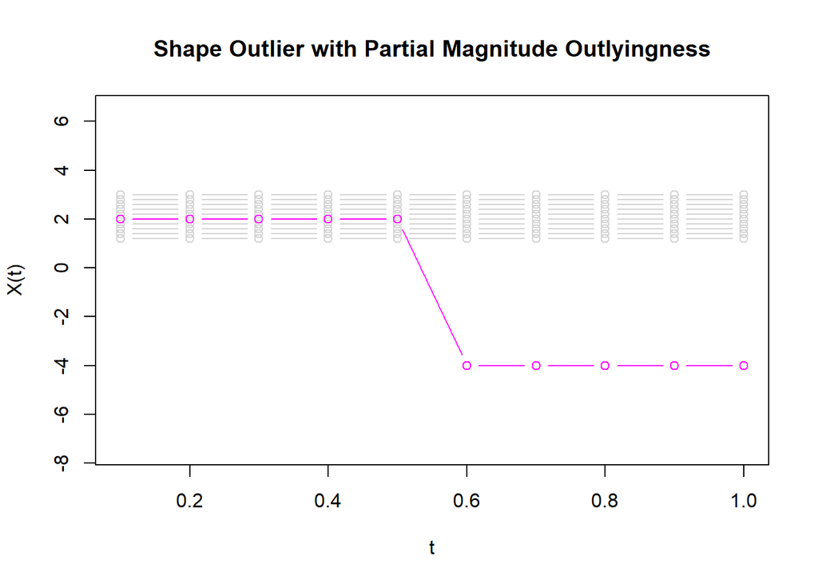

```
## $legend
## $legend[[1]]
## [1] "f=shape outlier with partial mangitude outlyingness"
##
## $legend[[2]]
## [1] "pointwiseMedian=pointwise median"
##
##
## $results
##                            [,1]  [,2]  [,3]  [,4]  [,5]  [,6]  [,7]  [,8]  [,9] [,10]
## t                         0.100 0.200 0.300 0.400 0.500 0.600 0.700 0.800 0.900 1.000
## Var(R_pointwiseMedian(t)) 0.248 0.248 0.248 0.248 0.248 0.248 0.248 0.248 0.248 0.248
## Var(R_f(t))               0.248 0.248 0.248 0.248 0.248 0.083 0.083 0.083 0.083 0.083
## Var(E(R_f(t)|R_f(t-Δ)))      NA 0.248 0.248 0.248 0.248 0.007 0.083 0.083 0.083 0.083
## E(Var(R_f(t)|R_f(t-Δ)))      NA 0.000 0.000 0.000 0.000 0.076 0.000 0.000 0.000 0.000
```

```r
# data
nonOutlierMatrix<-matrix(data=rep(x=seq(from=3.0,to=1.2,by=-0.2),times=10),nrow=10,ncol=10)
pureMagnitudeOutlierMatrix<-matrix(data=rep(x=-3.0,times=10),nrow=1,ncol=10)
pureShapeOutlierMatrix<-matrix(data=rep(x=c(1.6,2.4),times=5),nrow=1,ncol=10)
shapeOutlierWithPartialMagnitudeOutlyingnessMatrix<-matrix(data=rep(x=c(2.0,-4.0),each=5),nrow=1,ncol=10)

# data visualization and save figures and tables
outliers<-list(pureMagnitudeOutlierMatrix,pureShapeOutlierMatrix,shapeOutlierWithPartialMagnitudeOutlyingnessMatrix)
outlierColors<-c("blue","red","magenta")
plotTitles<-c("Pure Magnitude Outlier","Pure Shape Outlier","Shape Outlier with Partial Magnitude Outlyingness")
tableLegend<-c("f=pure magnitude outlier","f=pure shape outlier","f=shape outlier with partial mangitude outlyingness")
ylim<-createylim(dataMatrix=rbind(nonOutlierMatrix,pureMagnitudeOutlierMatrix,pureShapeOutlierMatrix,shapeOutlierWithPartialMagnitudeOutlyingnessMatrix))
originalOptions<-options()
for(index in 1:3){
  createFigure1(nonOutlierMatrix=nonOutlierMatrix,outlierMatrix=outliers[[index]],color=outlierColors[index],ylim=ylim,title=plotTitles[index])
  plot<-recordPlot()
  png(file=paste("output/figure_1/figure_1_",index,".png",sep=""))
  replayPlot(x=plot)
  invisible(x=dev.off())
  table<-pointwiseVariationDepthOfOutlierFigure1(nonOutlierMatrix=nonOutlierMatrix,outlierMatrix=outliers[[index]],legend=list(tableLegend[index],"pointwiseMedian=pointwise median"))
  options(width=100)
  print(x=table)
  capture.output(table,file=paste("output/figure_1/figure_1_",index,"_table.txt",sep=""))
  options(width=originalOptions$width)
}
```

Given the results of the test below, and  
since both $D_f(t)$ and $Var(E(R_f(t)|R_f(t-\Delta)))$ depend on pointwise rank but not on pointwise magnitude values or additional differences,  
based on $11$ observations at $p$ time points $\{0.1,...,1.0\}$,  
where $10$ observations are constant and take $10$ different values,  
$D_f(t)=0.217$ for all $t\in\{0.1,...,1.0\}$ with the shape components being $0.043$ and $0.050$ iteratively over time  
doesn’t seem to be possible for any $f$.

```r
index<-2
fRange<-seq(from=3.0,to=1.0,by=-0.2)
options(width=90)
for(ftOdd in fRange){
  for(ftEven in fRange){
    f<-matrix(data=rep(x=c(ftOdd,ftEven),times=5),nrow=1,ncol=10)
    results<-pointwiseVariationDepthOfOutlierFigure1(nonOutlierMatrix=nonOutlierMatrix,outlierMatrix=f,legend=list(tableLegend[index],"pointwiseMedian=pointwise median"))$results
    if((results["Var(R_f(t))",2]==0.217)|(results["Var(E(R_f(t)|R_f(t-Δ)))",2]==0.043)|(results["Var(E(R_f(t)|R_f(t-Δ)))",2]==0.050)){
      print(x=list(ftOdd=ftOdd,ftEven=ftEven,results=results[c("Var(R_f(t))","Var(E(R_f(t)|R_f(t-Δ)))"),]))
    }
  }
}
options(width=originalOptions$width)
```

```
## $ftOdd
## [1] 2.4
##
## $ftEven
## [1] 1.6
##
## $results
##                          [,1]  [,2]  [,3]  [,4]  [,5]  [,6]  [,7]  [,8]  [,9] [,10]
## Var(R_f(t))             0.198 0.231 0.198 0.231 0.198 0.231 0.198 0.231 0.198 0.231
## Var(E(R_f(t)|R_f(t-Δ)))    NA 0.050 0.043 0.050 0.043 0.050 0.043 0.050 0.043 0.050
##
## $ftOdd
## [1] 2.2
##
## $ftEven
## [1] 1.4
##
## $results
##                          [,1]  [,2]  [,3]  [,4]  [,5]  [,6]  [,7]  [,8]  [,9] [,10]
## Var(R_f(t))             0.231 0.198 0.231 0.198 0.231 0.198 0.231 0.198 0.231 0.198
## Var(E(R_f(t)|R_f(t-Δ)))    NA 0.043 0.050 0.043 0.050 0.043 0.050 0.043 0.050 0.043
##
## $ftOdd
## [1] 1.6
##
## $ftEven
## [1] 2.4
##
## $results
##                          [,1]  [,2]  [,3]  [,4]  [,5]  [,6]  [,7]  [,8]  [,9] [,10]
## Var(R_f(t))             0.231 0.198 0.231 0.198 0.231 0.198 0.231 0.198 0.231 0.198
## Var(E(R_f(t)|R_f(t-Δ)))    NA 0.043 0.050 0.043 0.050 0.043 0.050 0.043 0.050 0.043
##
## $ftOdd
## [1] 1.4
##
## $ftEven
## [1] 2.2
##
## $results
##                          [,1]  [,2]  [,3]  [,4]  [,5]  [,6]  [,7]  [,8]  [,9] [,10]
## Var(R_f(t))             0.198 0.231 0.198 0.231 0.198 0.231 0.198 0.231 0.198 0.231
## Var(E(R_f(t)|R_f(t-Δ)))    NA 0.050 0.043 0.050 0.043 0.050 0.043 0.050 0.043 0.050
```

## Figures 2, 3, 4

```r
# number of samples
n<-100

# number of time points
p<-50

# time row
timeRow<-createTimeRow(p=p)

# data
sampleList<-list()
outlierMatrix<-matrix(data=NA,nrow=7,ncol=p)
for(modelNumber in 1:7){
  samples<-match.fun(FUN=paste("createModel",modelNumber,"Samples",sep=""))(n=n,p=p)$samples
  sampleList[[modelNumber]]<-samples
  if(1<modelNumber){
    functionalBoxplotMSSTVD<-createFunctionalBoxplotMSSTVD(dataMatrix=samples)
  }
  if(modelNumber==2){
    outlierMatrix[modelNumber,]<-samples[functionalBoxplotMSSTVD$magnitudeOutlierIndicesInIncreasingOrderByTVD[1],]
  }else if(2<modelNumber){
    outlierMatrix[modelNumber,]<-samples[functionalBoxplotMSSTVD$shapeOutlierIndicesInIncreasingOrderByMSS[1],]
  }
}
model7BaseSamples<-createModel7BaseSamples(n=n,p=p)$samples
nonOutlierMatrix<-sampleList[[1]]
dataMatrix<-rbind(nonOutlierMatrix,outlierMatrix[2:6,])
ylim<-createylim(dataMatrix=dataMatrix)
```

According to the test below,  
`createFunctionalBoxplotMSSTVD()` detects the same outliers as `detectOutlier()`,  
even though the calculation of $TVD(f)$ might need to be modified in `detectOutlier()`.

```r
# test
sameOutliers<-TRUE
for(modelNumber in 1:7){
  samples<-sampleList[[modelNumber]]
  functionalBoxplotMSSTVD<-createFunctionalBoxplotMSSTVD(dataMatrix=samples)
  outlierIndicesTest<-detectOutlier(data=t(x=samples),nCurve=n,nPoint=p,empFactor=3)
  shapeOutlierIndices<-sort(x=functionalBoxplotMSSTVD$shapeOutlierIndicesInIncreasingOrderByMSS)
  shapeOutlierIndicesTest<-sort(x=outlierIndicesTest$sOut)
  numberOfShapeOutlierIndices<-length(x=shapeOutlierIndices)
  numberOfShapeOutlierIndicesTest<-length(x=shapeOutlierIndicesTest)
  magnitudeOutlierIndices<-sort(x=functionalBoxplotMSSTVD$magnitudeOutlierIndicesInIncreasingOrderByTVD)
  magnitudeOutlierIndicesTest<-sort(x=outlierIndicesTest$mOut)
  numberOfMagnitudeOutlierIndices<-length(x=magnitudeOutlierIndices)
  numberOfMagnitudeOutlierIndicesTest<-length(x=magnitudeOutlierIndicesTest)
  if(numberOfShapeOutlierIndices!=0&numberOfShapeOutlierIndicesTest==0|(0<numberOfShapeOutlierIndices&0<numberOfShapeOutlierIndicesTest&!all(shapeOutlierIndices==shapeOutlierIndicesTest))|numberOfMagnitudeOutlierIndices!=0&numberOfMagnitudeOutlierIndicesTest==0|(0<numberOfMagnitudeOutlierIndices&0<numberOfMagnitudeOutlierIndicesTest&!all(magnitudeOutlierIndices==magnitudeOutlierIndicesTest))){
    sameOutliers<-FALSE
    break
  }
}
print(x=sameOutliers)
```

```
## [1] TRUE
```

### Figure 2 (c)

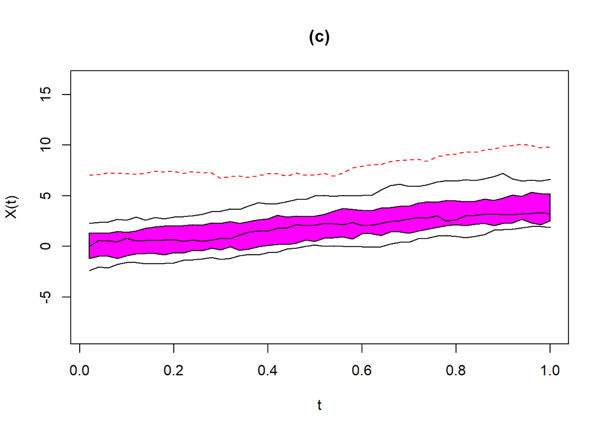

```r
functionalBoxplotMSSTVD<-createFunctionalBoxplotMSSTVD(dataMatrix=dataMatrix,plot=TRUE,plotTitle="(c)")

# save figure
plot<-recordPlot()
png(file="output/figure_2/figure_2_c.png")
replayPlot(x=plot)
invisible(x=dev.off())
```

### Figure 2 (a)

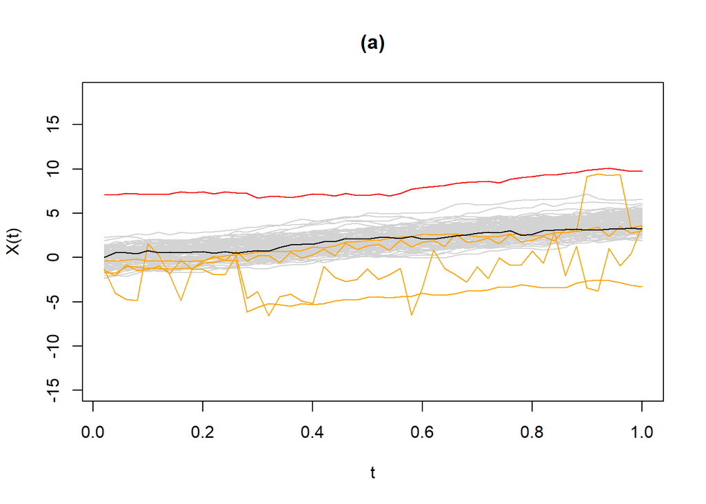

```r
# plot non-outliers
matplot(x=timeRow,y=t(x=nonOutlierMatrix),type="l",lty=1,pch=1,col="lightgrey",xlab="t",ylab="X(t)",ylim=ylim,main="(a)")

# plot outliers
outlierColors=c(NA,"red",rep(x="orange",times=4))
for(outlierIndex in 2:6){
  lines(x=timeRow,y=outlierMatrix[outlierIndex,],col=outlierColors[outlierIndex])
}

# plot functional median
functionalMedianIndex<-functionalBoxplotMSSTVD$functionalMedianIndex
functionalMedianRow<-dataMatrix[functionalMedianIndex,]
lines(x=timeRow,y=functionalMedianRow)

# save figure
plot<-recordPlot()
png(file="output/figure_2/figure_2_a.png")
replayPlot(x=plot)
invisible(x=dev.off())
```

### Figure 2 (b)

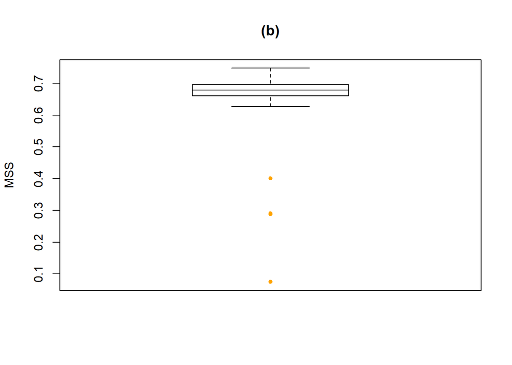

```r
MSSfColumn<-createMSSfColumn(dataMatrix=dataMatrix)
factor<-3
boxplot(x=MSSfColumn,range=factor,col="white",medlwd=1,outpch=20,outcol="orange",ylab="MSS",main="(b)")

# save figure
plot<-recordPlot()
png(file="output/figure_2/figure_2_b.png")
replayPlot(x=plot)
invisible(x=dev.off())
```

According to the test below,  
the boxplots for $MSS(f,\Delta)$ values of `createMSSfColumn()` and `TVDMSS()` look identical.

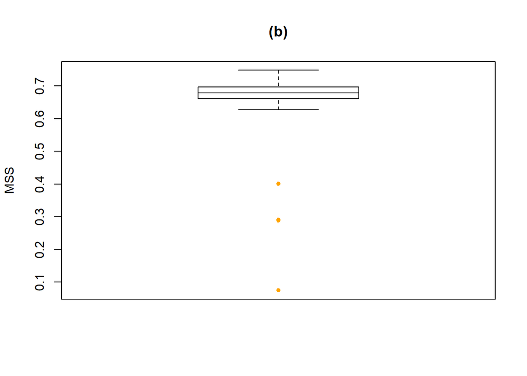

```r
# test
n<-n+5
MSSfColumn<-TVDMSS(data=t(x=dataMatrix),nCurve=n,nPoint=p)$MSS
boxplot(x=MSSfColumn,range=factor,col="white",medlwd=1,outpch=20,outcol="orange",ylab="MSS",main="(b)")
```

### Figure 3 Top

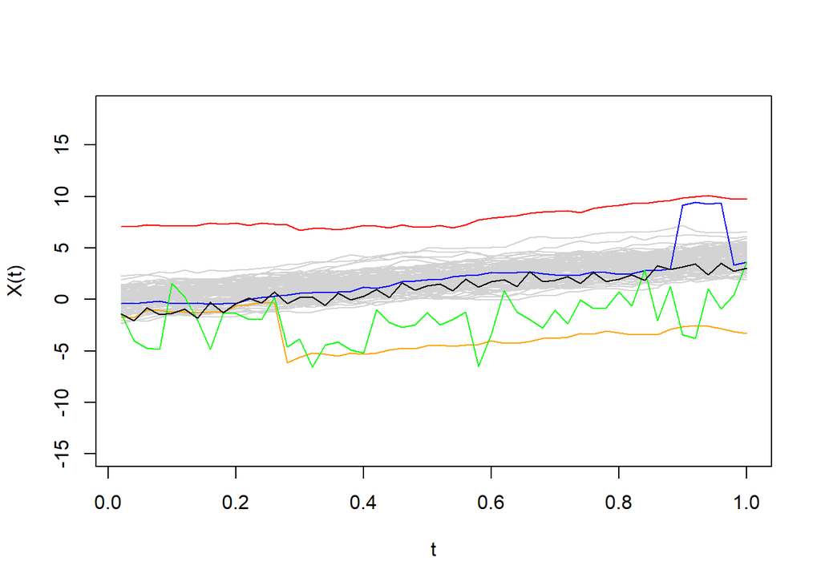

```r
# plot non-outliers
matplot(x=timeRow,y=t(x=nonOutlierMatrix),type="l",lty=1,pch=1,col="lightgrey",xlab="t",ylab="X(t)",ylim=ylim)

# plot outliers
outlierColors=c(NA,"red","orange","blue","green","black")
for(outlierIndex in 2:6){
  lines(x=timeRow,y=outlierMatrix[outlierIndex,],col=outlierColors[outlierIndex])
}

# save figure
plot<-recordPlot()
png(file="output/figure_3/figure_3_top.png")
replayPlot(x=plot)
invisible(x=dev.off())
```

### Figure 3 Bottom

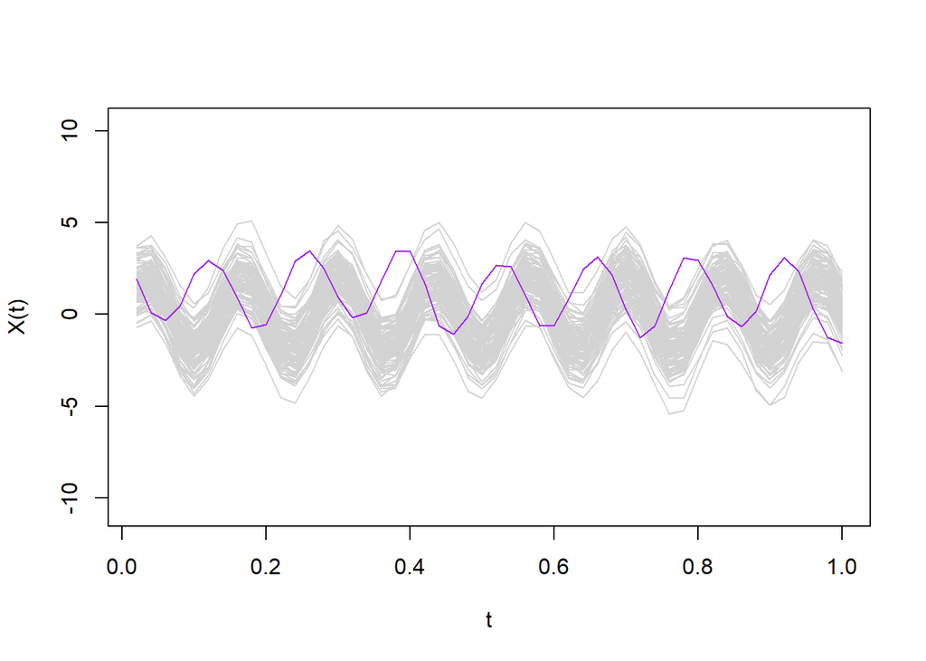

```r
# plot non-oultiers
outlier<-outlierMatrix[7,]
ylim<-createylim(dataMatrix=rbind(model7BaseSamples,outlier))
matplot(x=timeRow,y=t(x=model7BaseSamples),type="l",lty=1,pch=1,col="lightgrey",xlab="t",ylab="X(t)",ylim=ylim)

# plot outlier
lines(x=timeRow,y=outlier,col="purple")

# save figure
plot<-recordPlot()
png(file="output/figure_3/figure_3_bottom.png")
replayPlot(x=plot)
invisible(x=dev.off())
```

### Figure 4

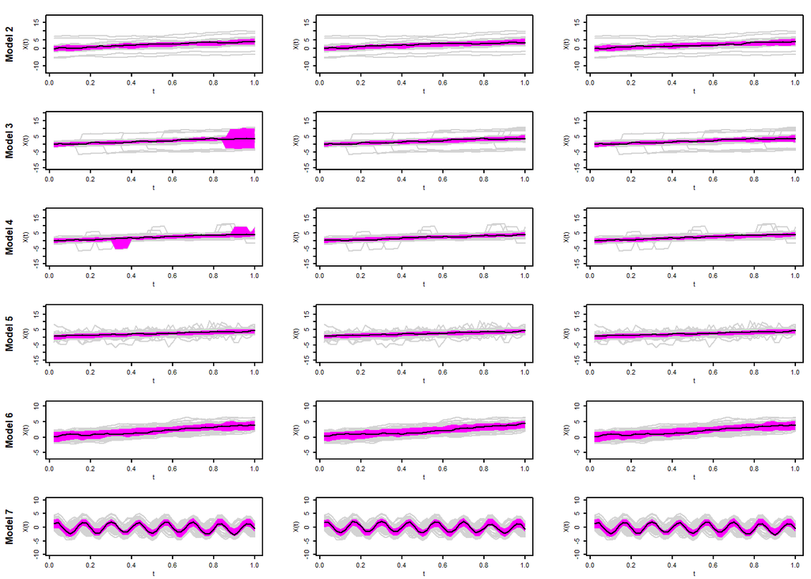

```r
depthVector=c("MBD","ED","MSSTVD")
originalPar<-par()
par(mfrow=c(6,3),mar=c(1.5,3,1,0.5))
for(modelNumber in 2:7){
  for(depth in depthVector){
    createFigure4(dataMatrix=sampleList[[modelNumber]],depth=depth)
    if(modelNumber==2){
      if(depth=="MSSTVD"){
        text<-"TVD+MSS"
      }else{
        text<-depth
      }
      mtext(side=1,text=text,line=-7,cex=0.5,font=2)
    }
    if(depth=="MBD"){
      mtext(side=2,text=paste("Model",modelNumber),line=2,cex=0.5,font=2)
    }
  }
}
par(mfrow=originalPar$mfrow,mar=originalPar$mar)

# save figure
plot<-recordPlot()
png(file="output/figure_4/figure_4.png")
replayPlot(x=plot)
invisible(x=dev.off())
```

## Table 1

The code below takes approximately $3$ minutes to run on a 1.6 GHz Intel Core i5-8250U processor.

```r
# number of samples
n<-100

# number of time points
p<-50

# data
resultsList<-list()
progressBar<-progress_estimated(n=4*7,progress_location=file(description="progress/table_1_chunk_1.txt",open="w"))
for(depthIndex in 1:4){
  resultsListGivenDepth<-list()
  for(modelNumber in 1:7){
    update_progress(.pb=progressBar)
    resultsListGivenDepthAndModel<-list()
    for(experimentNumber in 1:500){
      resultsListGivenDepthAndModel[[experimentNumber]]<-match.fun(FUN=paste("createModel",modelNumber,"Samples",sep=""))(n=n,p=p)
    }
    resultsListGivenDepth[[modelNumber]]<-resultsListGivenDepthAndModel
  }
  resultsList[[depthIndex]]<-resultsListGivenDepth
}
```

The code below takes approximately $4$ hours and $30$ minutes to run on a 1.6 GHz Intel Core i5-8250U processor.

```r
# table and save table
depthVector=c("MSSTVD","MBD","ED","MSS")
table1<-matrix(data=NA,nrow=4,ncol=14)
progressBar<-progress_estimated(n=4*7,progress_location=file(description="progress/table_1_chunk_2.txt",open="w"))
for(depthIndex in 1:4){
  depth<-depthVector[depthIndex]
  for(modelNumber in 1:7){
    update_progress(.pb=progressBar)
    TPRVector<-c()
    FPRVector<-c()
    for(experimentNumber in 1:500){
      results<-resultsList[[depthIndex]][[modelNumber]][[experimentNumber]]
      trueOutlierIndices<-results$outlierIndices
      numberOfTrueOutliers<-length(x=trueOutlierIndices)
      samples<-results$samples
      if(depth=="MSSTVD"){
        functionalBoxplotMSSTVD<-createFunctionalBoxplotMSSTVD(dataMatrix=samples)
        detectedOutlierIndices<-c(functionalBoxplotMSSTVD$shapeOutlierIndicesInIncreasingOrderByMSS,functionalBoxplotMSSTVD$magnitudeOutlierIndicesInIncreasingOrderByTVD)
      }else if(depth=="MSS"){
        detectedOutlierIndices<-detectOutlierIndicesBoxplot(dataMatrix=samples,depth=depth,factor=3)
      }else{
        detectedOutlierIndices<-createFunctionalBoxplot(dataMatrix=samples,depth=depth,factor=1.5)$outlierIndicesInIncreasingOrderByDepth
      }
      correctlyDetectedOutlierIndices<-intersect(x=trueOutlierIndices,y=detectedOutlierIndices)
      numberOfCorrectlyDetectedOutliers<-length(x=correctlyDetectedOutlierIndices)
      if(numberOfTrueOutliers==0){
        TPR<-NA
      }else{
        TPR<-numberOfCorrectlyDetectedOutliers/numberOfTrueOutliers
      }
      TPRVector<-c(TPRVector,TPR)
      numberOfTrueNonOutliers<-n-numberOfTrueOutliers
      numberOfDetectedOutliers<-length(x=detectedOutlierIndices)
      numberOfWronglyDetectedOutliers<-numberOfDetectedOutliers-numberOfCorrectlyDetectedOutliers
      if(numberOfTrueNonOutliers==0){
        FPR<-NA
      }else{
        FPR<-numberOfWronglyDetectedOutliers/numberOfTrueNonOutliers
      }
      FPRVector<-c(FPRVector,FPR)
    }
    TPRMean<-round(x=mean(x=TPRVector)*100,digits=2)
    TPRStandardDeviation<-round(x=sd(x=TPRVector)*100,digits=2)
    FPRMean<-round(x=mean(x=FPRVector)*100,digits=2)
    FPRStandardDeviation<-round(x=sd(x=FPRVector)*100,digits=2)
    table1[depthIndex,2*modelNumber-1]<-paste(TPRMean,"(",TPRStandardDeviation,")",sep="")
    table1[depthIndex,2*modelNumber]<-paste(FPRMean,"(",FPRStandardDeviation,")",sep="")
  }
}
colnames(x=table1)<-paste("Model",rep(x=1:7,each=2),rep(x=c("TPR","FPR"),times=7))
rownames(x=table1)<-c("TVD+MSS",depthVector[-1])
table<-noquote(obj=table1[,-1])
options(width=100)
print(x=table)
capture.output(table,file=paste("output/table_1/table_1.txt",sep=""))
options(width=originalOptions$width)
```

```
##
##         Model 1 FPR Model 2 TPR Model 2 FPR Model 3 TPR  Model 3 FPR Model 4 TPR  Model 4 FPR
## TVD+MSS 0.07(0.26)  99.06(3.07) 0.03(0.21)  100(0)       0.04(0.19)  100(0)       0.04(0.21)
## MBD     0.09(0.32)  99.26(2.81) 0.05(0.22)  82.72(14.41) 0.02(0.14)  44.2(18.27)  0.05(0.22)
## ED      0.04(0.2)   98.44(4.38) 0.01(0.12)  87.5(12.38)  0.02(0.16)  85.78(12.77) 0.01(0.12)
## MSS     0(0)        0.02(0.45)  0(0)        97.84(4.85)  0(0)        100(0)       0(0)
##         Model 5 TPR  Model 5 FPR Model 6 TPR Model 6 FPR Model 7 TPR  Model 7 FPR
## TVD+MSS 100(0)       0.03(0.19)  99.86(1.46) 0.02(0.14)  99.81(4.29)  0.02(0.18)
## MBD     64.29(17.48) 0.03(0.19)  0.06(0.89)  0.08(0.34)  45.89(24.54) 0.04(0.19)
## ED      62.4(18.83)  0.02(0.16)  0.03(0.53)  0.02(0.16)  35.81(23.43) 0.02(0.13)
## MSS     100(0)       0(0)        99.87(1.48) 0(0)        100(0)       0(0)
```

The code below takes approximately $6$ minutes to run on a 1.6 GHz Intel Core i5-8250U processor.

```r
# test
table1Test<-matrix(data=NA,nrow=4,ncol=14)
progressBar<-progress_estimated(n=4*7,progress_location=file(description="progress/table_1_test.txt",open="w"))
for(depthIndex in 1:4){
  if(depthIndex==3){
    next
  }
  depth<-depthVector[depthIndex]
  for(modelNumber in 1:7){
    update_progress(.pb=progressBar)
    TPRVector<-c()
    FPRVector<-c()
    for(experimentNumber in 1:500){
      results<-resultsList[[depthIndex]][[modelNumber]][[experimentNumber]]
      trueOutlierIndices<-results$outlierIndices
      numberOfTrueOutliers<-length(x=trueOutlierIndices)
      samples<-results$samples
      if(depth=="MSSTVD"){
        detectedOutlierIndices<-detectOutlier(data=t(x=samples),nCurve=n,nPoint=p,empFactor=3)$outlier
      }else if(depth=="MBD"){
        detectedOutlierIndices<-fbplot(fit=t(x=samples),plot=FALSE)$outpoint
      }else if(depth=="MSS"){
        detectedOutlierIndices<-detectOutlier(data=t(x=samples),nCurve=n,nPoint=p,empFactor=3)$sOut
      }
      correctlyDetectedOutlierIndices<-intersect(x=trueOutlierIndices,y=detectedOutlierIndices)
      numberOfCorrectlyDetectedOutliers<-length(x=correctlyDetectedOutlierIndices)
      if(numberOfTrueOutliers==0){
        TPR<-NA
      }else{
        TPR<-numberOfCorrectlyDetectedOutliers/numberOfTrueOutliers
      }
      TPRVector<-c(TPRVector,TPR)
      numberOfTrueNonOutliers<-n-numberOfTrueOutliers
      numberOfDetectedOutliers<-length(x=detectedOutlierIndices)
      numberOfWronglyDetectedOutliers<-numberOfDetectedOutliers-numberOfCorrectlyDetectedOutliers
      if(numberOfTrueNonOutliers==0){
        FPR<-NA
      }else{
        FPR<-numberOfWronglyDetectedOutliers/numberOfTrueNonOutliers
      }
      FPRVector<-c(FPRVector,FPR)
    }
    TPRMean<-round(x=mean(x=TPRVector)*100,digits=2)
    TPRStandardDeviation<-round(x=sd(x=TPRVector)*100,digits=2)
    FPRMean<-round(x=mean(x=FPRVector)*100,digits=2)
    FPRStandardDeviation<-round(x=sd(x=FPRVector)*100,digits=2)
    table1Test[depthIndex,2*modelNumber-1]<-paste(TPRMean,"(",TPRStandardDeviation,")",sep="")
    table1Test[depthIndex,2*modelNumber]<-paste(FPRMean,"(",FPRStandardDeviation,")",sep="")
  }
}
print(x=all(table1[-3,]==table1Test[-3,]))
```

```
## [1] FALSE
```

## Figure 5

```r
# data
# source: Climate Prediction Center Internet Team. (2021, January 21). Monthly Atmospheric & Sea Surface Temperature Indices. Climate Prediction Center. https://www.cpc.ncep.noaa.gov/data/indices/sstoi.indices
dataMatrix<-read.csv("data/figure_5_data.txt",sep="")
firstIndex<-which(dataMatrix$YR==1982&dataMatrix$MON==7)
lastIndex<-which(dataMatrix$YR==2016&dataMatrix$MON==6)
yearMatrix<-matrix(data=dataMatrix[firstIndex:lastIndex,"YR"],ncol=12,byrow=TRUE)
SSTMatrix<-matrix(data=dataMatrix[firstIndex:lastIndex,"NINO1.2"],ncol=12,byrow=TRUE)

p<-12
```

### Figure 5 (c)

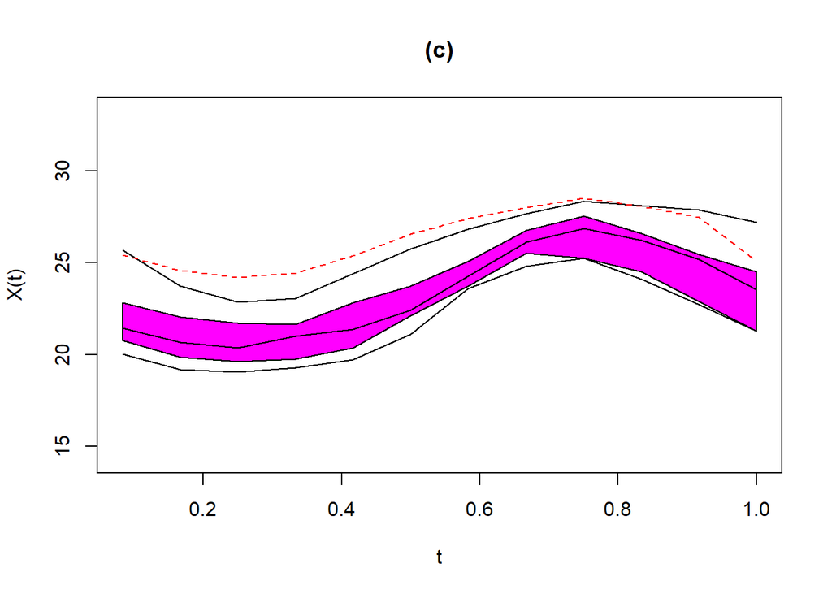

```r
functionalBoxplotMSSTVD<-createFunctionalBoxplotMSSTVD(dataMatrix=SSTMatrix,plot=TRUE,plotTitle="(c)")

# save figure
plot<-recordPlot()
png(file="output/figure_5/figure_5_c.png")
replayPlot(x=plot)
invisible(x=dev.off())
```

### Figure 5 (a)

```r
# plot data
timeRow<-createTimeRow(p=p)
ylim<-createylim(dataMatrix=SSTMatrix)
matplot(x=timeRow,y=t(x=SSTMatrix),type="l",lty=1,col="lightgrey",xlab="month",ylab="SST",ylim=ylim,xaxt="n",main="(a)")
axis(side=1,at=c(0.25,0.5,0.75,1),labels=c(9,12,3,6))
```

According to the test below,  
my Figure 5 (a) has $34$ curves,  
while the paper’s Figure 5 (a) has $35$ curves,  
and I’m not sure about the reason for the difference.

```r
# test
n<-nrow(x=SSTMatrix)
print(x=n)
```

```
## [1] 34
```

```r
# plot magnitude outliers
magnitudeOutlierIndices<-functionalBoxplotMSSTVD$magnitudeOutlierIndicesInIncreasingOrderByTVD
magnitudeOutliers<-SSTMatrix[magnitudeOutlierIndices,]
lines(x=timeRow,y=magnitudeOutliers,col="red")
arrows(x0=0.25,y0=27.5,x1=0.5,y1=SSTMatrix[magnitudeOutlierIndices,6],length=0.1)
text(x=0.25,y=28.75,labels=paste(yearMatrix[magnitudeOutlierIndices,1],"-",yearMatrix[magnitudeOutlierIndices,12]))
```

According to the test below,  
`createFunctionalBoxplotMSSTVD()` detects the same magnitude outliers as `detectOutlier()`.

```r
# test
sort(x=magnitudeOutlierIndices)==sort(x=detectOutlier(data=t(x=SSTMatrix),nCurve=n,nPoint=p,empFactor=3)$mOut)
```

```
## [1] TRUE
```

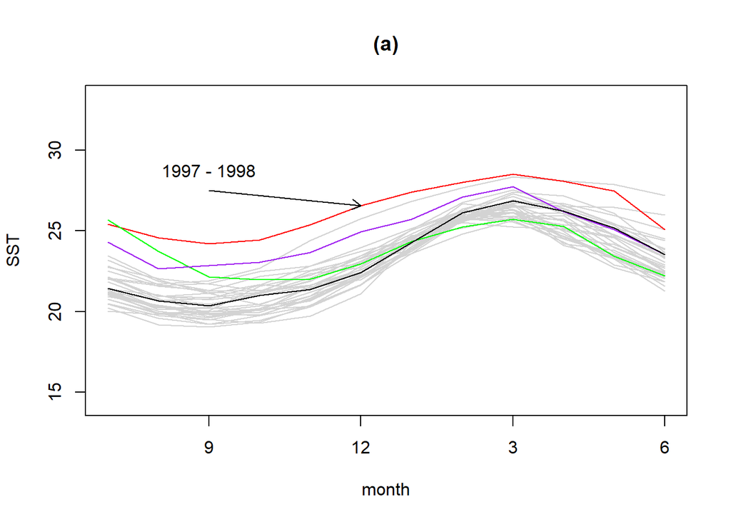

```r
# plot green line
greenLineIndex<-which(x=yearMatrix[,1]==1983)
greenLine<-SSTMatrix[greenLineIndex,]
lines(x=timeRow,y=greenLine,col="green")

# plot purple line
purpleLineIndex<-which(x=yearMatrix[,1]==2015)
purpleLine<-SSTMatrix[purpleLineIndex,]
lines(x=timeRow,y=purpleLine,col="purple")

# plot functional median
functionalMedianIndex<-functionalBoxplotMSSTVD$functionalMedianIndex
functionalMedian<-SSTMatrix[functionalMedianIndex,]
lines(x=timeRow,y=functionalMedian)

# save figure
plot<-recordPlot()
png(file="output/figure_5/figure_5_a.png")
replayPlot(x=plot)
invisible(x=dev.off())
```

### Figure 5 (b)

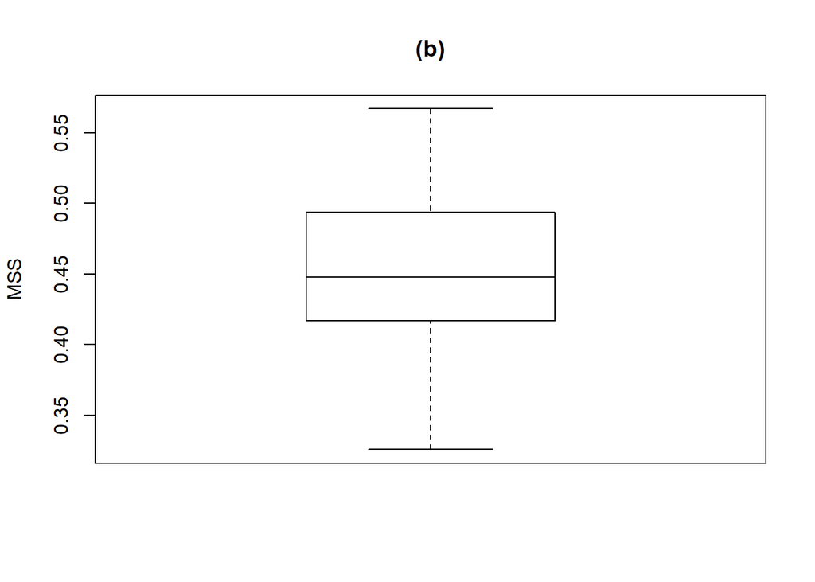

```r
MSSfColumn<-createMSSfColumn(dataMatrix=SSTMatrix)
factor<-3
boxplot(x=MSSfColumn,range=factor,col="white",medlwd=1,ylab="MSS",main="(b)")

# save figure
plot<-recordPlot()
png(file="output/figure_5/figure_5_b.png")
replayPlot(x=plot)
invisible(x=dev.off())
```

According to the test below,  
the boxplots for $MSS(f,\Delta)$ values of `createMSSfColumn()` and `TVDMSS()` look identical.

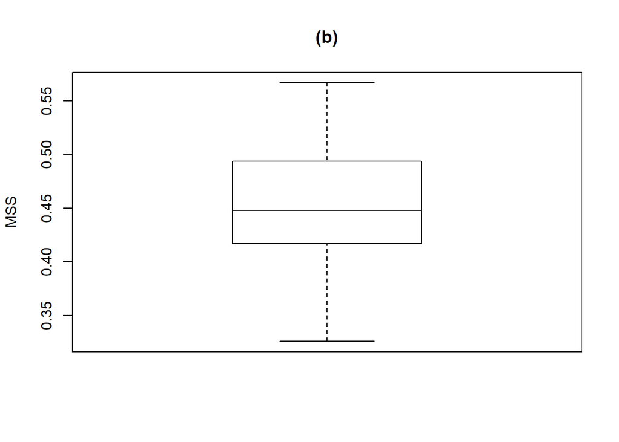

```r
# test
MSSfColumn<-TVDMSS(data=t(x=SSTMatrix),nCurve=n,nPoint=p)$MSS
boxplot(x=MSSfColumn,range=factor,col="white",medlwd=1,ylab="MSS",main="(b)")
```